# chapter5

Abushahba

December 6, 2017

# Dimensionality reduction techniques

In this part we will analyse a data set named *humanW*, it originates from the United Nations Development Programme. See [their data page](http://hdr.undp.org/en/content/human-development-index-hdi) for more information. For a nice overview see also [the calculating the human development indices pdf](http://hdr.undp.org/sites/default/files/hdr2015_technical_notes.pdf). Most of the variable names in the data have been shortened and two new variables have been computed. See the [meta file](https://raw.githubusercontent.com/TuomoNieminen/Helsinki-Open-Data-Science/master/datasets/human_meta.txt). For the modified data please check our renamed variables and [wrangled raw data](https://github.com/Abushahba/IODS-project/blob/master/data/human.csv), as well as R script for [data wrangling](https://github.com/Abushahba/IODS-project/blob/master/data/create_human.R).

Now, let’s have a look on our data set, the data now have 155 observations and 8 variables.

```r
humanW <- read.csv(file =  "C:/Users/ahmed/Desktop/IODS-project/data/human.csv")
row.names(humanW) <- humanW$X
humanW <- humanW[-1]
dim(humanW)
```

```
## [1] 155   8
```

## Graphical overview of the data and summaries of the variables.

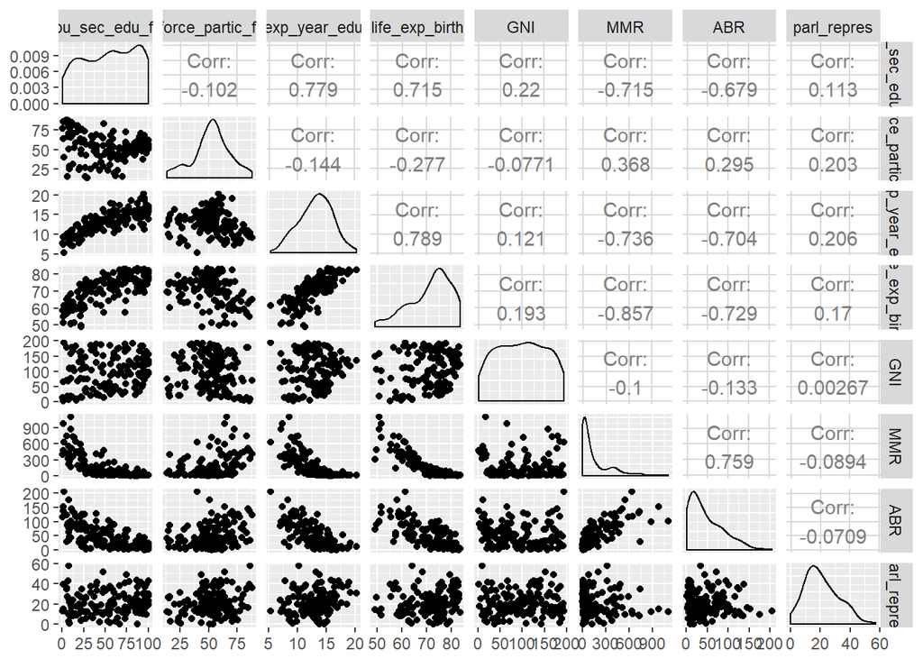

```r
library(ggplot2)
library(GGally)
library(dplyr)
library(corrplot)
p0 <- ggpairs(humanW)
p0
```

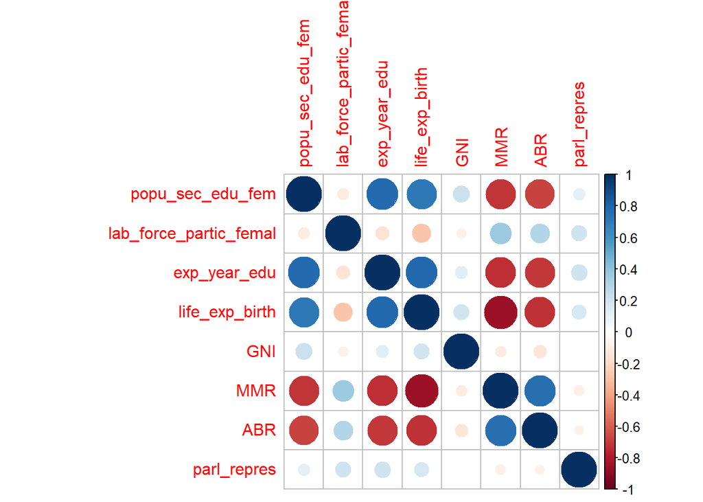

```r
cor(humanW) %>% corrplot()
```

## Principal component analysis (PCA) on the *not standardized* human data

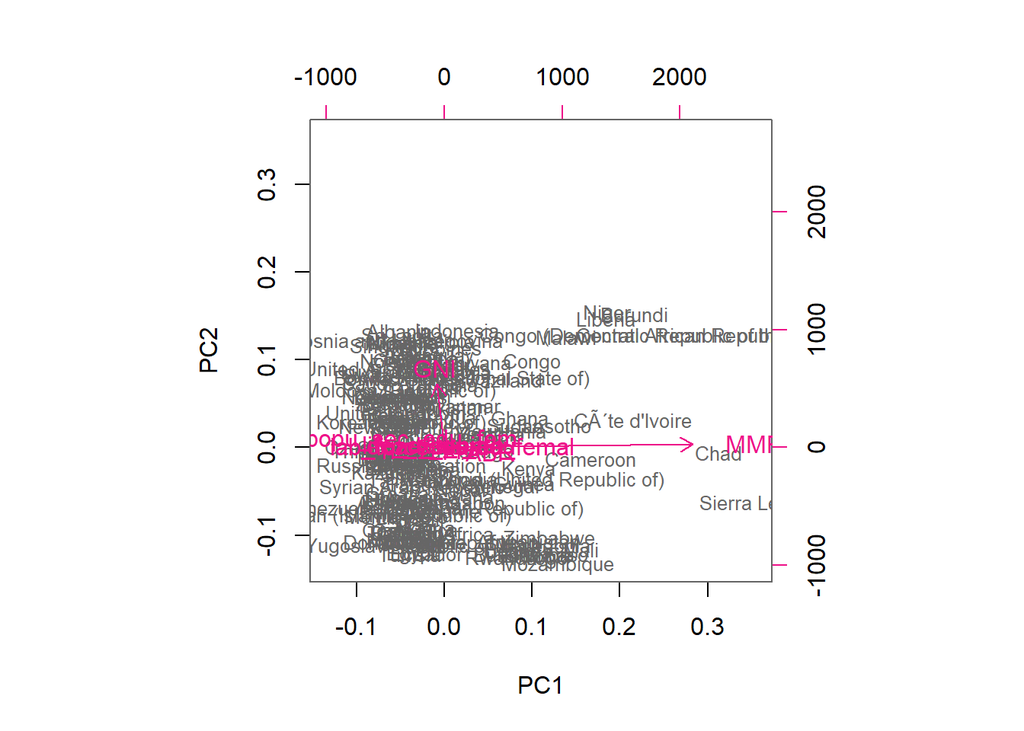

```r
pca_humanW1 <- prcomp(humanW)

# draw a biplot of the principal component representation and the original variables
biplot(pca_humanW1, choices = 1:2, cex = c(0.8, 1), col = c("grey40", "deeppink2"))
```

## Principal component analysis (PCA) on the *standardized* human data

```r
# standardize the variables
humanW_std <- scale(humanW)
humanW_std
```

[output not shown]

[output cut: 739 more lines]

[output not shown]

```r
# summaries of the standardized variables showing means equal to zero
summary(humanW_std)
```

```
##  popu_sec_edu_fem   lab_force_partic_femal  exp_year_edu
##  Min.   :-1.76122   Min.   :-2.43186       Min.   :-2.7378
##  1st Qu.:-0.91250   1st Qu.:-0.50289       1st Qu.:-0.6782
##  Median : 0.03967   Median : 0.06116       Median : 0.1140
##  Mean   : 0.00000   Mean   : 0.00000       Mean   : 0.0000
##  3rd Qu.: 0.96275   3rd Qu.: 0.58469       3rd Qu.: 0.7126
##  Max.   : 1.44288   Max.   : 2.21762       Max.   : 2.4730
##  life_exp_birth         GNI                 MMR               ABR
##  Min.   :-2.7188   Min.   :-1.767729   Min.   :-0.6992   Min.   :-1.1325
##  1st Qu.:-0.6425   1st Qu.:-0.826563   1st Qu.:-0.6496   1st Qu.:-0.8394
##  Median : 0.3056   Median : 0.004952   Median :-0.4726   Median :-0.3298
##  Mean   : 0.0000   Mean   : 0.000000   Mean   : 0.0000   Mean   : 0.0000
##  3rd Qu.: 0.6717   3rd Qu.: 0.818192   3rd Qu.: 0.1932   3rd Qu.: 0.6030
##  Max.   : 1.4218   Max.   : 1.741082   Max.   : 4.4899   Max.   : 3.8344
##   parl_repres
##  Min.   :-1.8203
##  1st Qu.:-0.7409
##  Median :-0.1403
##  Mean   : 0.0000
##  3rd Qu.: 0.6127
##  Max.   : 3.1850
```

Now, let’s perform PCA for the *standerdized* data

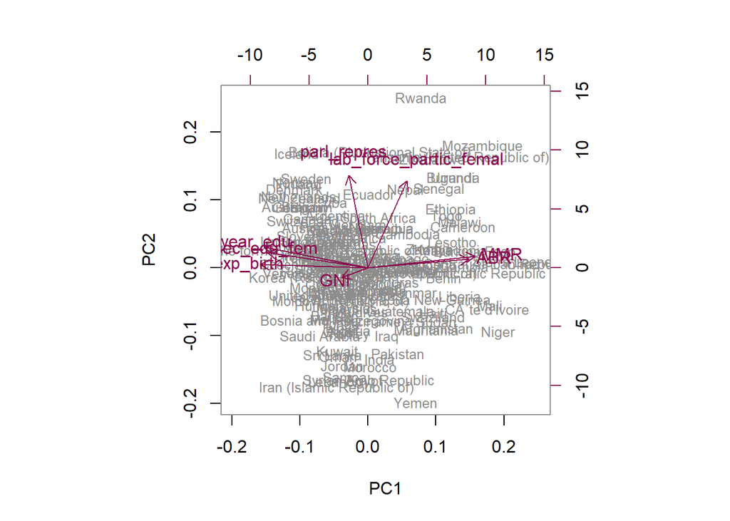

```r
#perform principal component analysis (with the SVD method)
pca_humanW2 <- prcomp(humanW_std)

# draw a biplot of the principal component representation and the original variables
biplot(pca_humanW2, choices = 1:2, cex = c(0.8, 1), col = c("grey55", "deeppink4"))
```

from the previous plots we can see that *Maternal mortality ratio* and *Adolescent birth rate* are contributing most to the PC1 with strong positive correlation with each other; meanwhile, they are quite negatively correlated to *Expected years of schooling*, *Life expectancy at birth* and *Proportion of females with at least secondary education*. However, all previous variables are very weakly correlated to * Proportion of females in the labour force* and *Percetange of female representatives in parliament* which are (the later) contributing more to the PC2. Such interpretation goes well with the former correlation matrix and is not feasible in the first biplot without standerdizing the variables for comparison.

## Analysing the first two principal component dimensions of the biplot

```r
s <- summary(pca_humanW2)

# rounded percetanges of variance captured by each PC
pca_pr <- round(100*s$importance[2, ], digits = 1)

# print out the percentages of variance
pca_pr
```

```
##  PC1  PC2  PC3  PC4  PC5  PC6  PC7  PC8
## 51.7 15.5 12.2  9.1  3.8  3.5  2.6  1.5
```

```r
# create object pc_lab to be used as axis labels
paste0(names(pca_pr), " (", pca_pr, "%)")
```

```
## [1] "PC1 (51.7%)" "PC2 (15.5%)" "PC3 (12.2%)" "PC4 (9.1%)"  "PC5 (3.8%)"
## [6] "PC6 (3.5%)"  "PC7 (2.6%)"  "PC8 (1.5%)"
```

```r
pc_lab <- paste0(names(pca_pr), " (", pca_pr, "%)")
pc_lab
```

```
## [1] "PC1 (51.7%)" "PC2 (15.5%)" "PC3 (12.2%)" "PC4 (9.1%)"  "PC5 (3.8%)"
## [6] "PC6 (3.5%)"  "PC7 (2.6%)"  "PC8 (1.5%)"
```

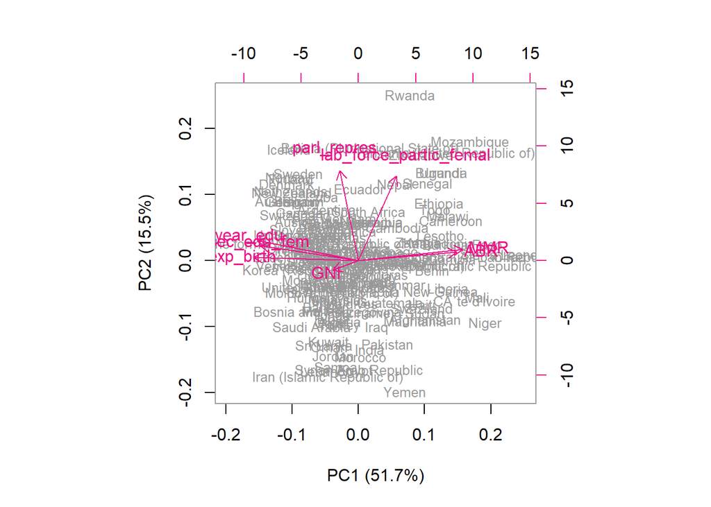

```r
# draw a biplot
biplot(pca_humanW2, cex = c(0.8, 1), col = c("grey60", "deeppink2"), xlab = pc_lab[1], ylab = pc_lab[2])
```

Here we can see that most of the variation is accounted for by the first two principal components which indicates validity of analysis. As we referred earlier *Maternal mortality ratio* and *Adolescent birth rate* are the most important variables which are found to be highly predicting less educational oppurtunities and shorter life span of related subjects. However, * Proportion of females in the labour force* and *Percetange of female representatives in parliament* seem to be related to other players which are not among our study variables.

## The tea dataset

```r
library(FactoMineR)
library(tidyr)
data(tea)
str(tea)
```

```
## 'data.frame':    300 obs. of  36 variables:
##  $ breakfast       : Factor w/ 2 levels "breakfast","Not.breakfast": 1 1 2 2 1 2 1 2 1 1 ...
##  $ tea.time        : Factor w/ 2 levels "Not.tea time",..: 1 1 2 1 1 1 2 2 2 1 ...
##  $ evening         : Factor w/ 2 levels "evening","Not.evening": 2 2 1 2 1 2 2 1 2 1 ...
##  $ lunch           : Factor w/ 2 levels "lunch","Not.lunch": 2 2 2 2 2 2 2 2 2 2 ...
##  $ dinner          : Factor w/ 2 levels "dinner","Not.dinner": 2 2 1 1 2 1 2 2 2 2 ...
##  $ always          : Factor w/ 2 levels "always","Not.always": 2 2 2 2 1 2 2 2 2 2 ...
##  $ home            : Factor w/ 2 levels "home","Not.home": 1 1 1 1 1 1 1 1 1 1 ...
##  $ work            : Factor w/ 2 levels "Not.work","work": 1 1 2 1 1 1 1 1 1 1 ...
##  $ tearoom         : Factor w/ 2 levels "Not.tearoom",..: 1 1 1 1 1 1 1 1 1 2 ...
##  $ friends         : Factor w/ 2 levels "friends","Not.friends": 2 2 1 2 2 2 1 2 2 2 ...
##  $ resto           : Factor w/ 2 levels "Not.resto","resto": 1 1 2 1 1 1 1 1 1 1 ...
##  $ pub             : Factor w/ 2 levels "Not.pub","pub": 1 1 1 1 1 1 1 1 1 1 ...
##  $ Tea             : Factor w/ 3 levels "black","Earl Grey",..: 1 1 2 2 2 2 2 1 2 1 ...
##  $ How             : Factor w/ 4 levels "alone","lemon",..: 1 3 1 1 1 1 1 3 3 1 ...
```

[output cut: 22 more lines]

```r
dim(tea)
```

```
## [1] 300  36
```

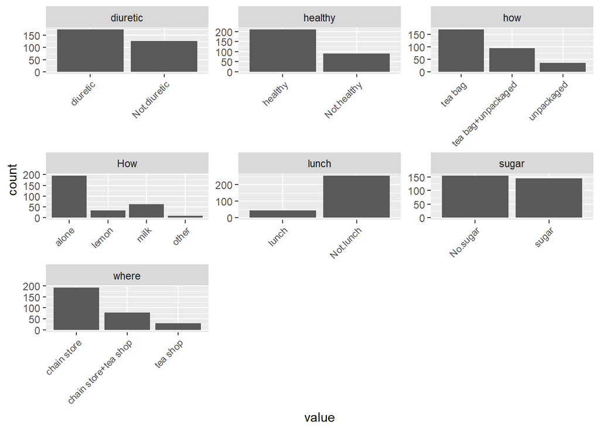

```r
keep_ <- c("How", "how", "sugar", "where", "lunch", "healthy", "diuretic")
teaW <- dplyr::select(tea, one_of(keep_))

gather(teaW) %>% ggplot(aes(value)) + facet_wrap("key", scales = "free") + geom_bar() + theme(axis.text.x = element_text(angle = 45, hjust = 1, size = 8))
```

then, let’s do Multiple Correspondence Analysis on the tea data

```r
# multiple correspondence analysis
mca <- MCA(teaW, graph = FALSE)

# summary of the model
summary(mca)
```

```
##
## Call:
## MCA(X = teaW, graph = FALSE)
##
##
## Eigenvalues
##                        Dim.1   Dim.2   Dim.3   Dim.4   Dim.5   Dim.6
## Variance               0.235   0.221   0.185   0.162   0.158   0.134
## % of var.             14.944  14.076  11.802  10.327  10.047   8.538
## Cumulative % of var.  14.944  29.020  40.822  51.149  61.196  69.734
##                        Dim.7   Dim.8   Dim.9  Dim.10  Dim.11
## Variance               0.123   0.116   0.101   0.079   0.057
## % of var.              7.837   7.402   6.396   5.026   3.606
## Cumulative % of var.  77.571  84.973  91.369  96.394 100.000
##
## Individuals (the 10 first)
##                       Dim.1    ctr   cos2    Dim.2    ctr   cos2    Dim.3
## 1                  | -0.537  0.409  0.410 | -0.234  0.082  0.078 |  0.177
## 2                  | -0.354  0.178  0.119 |  0.167  0.042  0.026 | -0.593
## 3                  | -0.311  0.137  0.164 | -0.029  0.001  0.001 | -0.617
## 4                  | -0.537  0.409  0.410 | -0.234  0.082  0.078 |  0.177
## 5                  | -0.356  0.179  0.147 | -0.212  0.068  0.052 | -0.263
## 6                  | -0.413  0.242  0.250 | -0.153  0.035  0.034 | -0.196
## 7                  | -0.413  0.242  0.250 | -0.153  0.035  0.034 | -0.196
## 8                  | -0.456  0.295  0.182 |  0.043  0.003  0.002 | -0.172
## 9                  |  0.315  0.141  0.051 |  0.516  0.400  0.137 |  0.543
## 10                 |  0.504  0.361  0.227 |  0.626  0.591  0.350 | -0.256
##                       ctr   cos2
## 1                   0.057  0.045 |
## 2                   0.632  0.335 |
## 3                   0.684  0.646 |
## 4                   0.057  0.045 |
## 5                   0.124  0.080 |
## 6                   0.069  0.056 |
## 7                   0.069  0.056 |
## 8                   0.053  0.026 |
## 9                   0.531  0.152 |
## 10                  0.118  0.058 |
##
## Categories (the 10 first)
```

[output cut: 17 more lines]

```
## tea bag+unpackaged   0.330   9.934 |   0.436   4.594   0.087   5.096 |
## unpackaged           0.371 -10.536 |  -0.322   0.956   0.014  -2.054 |
## No.sugar             0.018   2.317 |  -0.544  11.799   0.317  -9.734 |
## sugar                0.018  -2.317 |   0.582  12.613   0.317   9.734 |
## chain store          0.037  -3.335 |  -0.103   0.524   0.019  -2.378 |
##
## Categorical variables (eta2)
##                      Dim.1 Dim.2 Dim.3
## How                | 0.123 0.202 0.140 |
## how                | 0.675 0.562 0.089 |
## sugar              | 0.044 0.018 0.317 |
## where              | 0.755 0.613 0.054 |
## lunch              | 0.013 0.037 0.066 |
## healthy            | 0.005 0.076 0.240 |
## diuretic           | 0.029 0.040 0.392 |
```

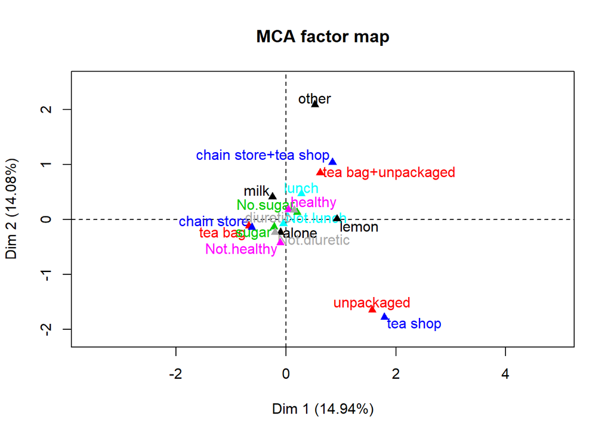

```r
# visualize MCA
plot(mca, invisible=c("ind"),habillage = "quali" )
```

here for example we can see that drinking unpackaged tea is more similar to drinking tea in tea shops, as well as, drinking tea in both chain stores and tea shops is more related to drinking both bagged and unpackaged tea category.